# WEEK 8

```python
import numpy as np
import pandas as pd
import matplotlib
import matplotlib.pyplot as plt
import seaborn as sns
```

```python
df = pd.read_csv(r'F:\COURSE\RAKAMIN\WEEK 8 - Data Visualization\WA_Fn-UseC_-Telco-Customer-Churn.csv')
df.head()
```

|  | customerID | gender | SeniorCitizen | Partner | Dependents | tenure | PhoneService | MultipleLines | InternetService | OnlineSecurity | ... | DeviceProtection | TechSupport | StreamingTV | StreamingMovies | Contract | PaperlessBilling | PaymentMethod | MonthlyCharges | TotalCharges | Churn |
| --- | --- | --- | --- | --- | --- | --- | --- | --- | --- | --- | --- | --- | --- | --- | --- | --- | --- | --- | --- | --- | --- |
| 0 | 7590-VHVEG | Female | 0 | Yes | No | 1 | No | No phone service | DSL | No | ... | No | No | No | No | Month-to-month | Yes | Electronic check | 29.85 | 29.85 | No |
| 1 | 5575-GNVDE | Male | 0 | No | No | 34 | Yes | No | DSL | Yes | ... | Yes | No | No | No | One year | No | Mailed check | 56.95 | 1889.5 | No |
| 2 | 3668-QPYBK | Male | 0 | No | No | 2 | Yes | No | DSL | Yes | ... | No | No | No | No | Month-to-month | Yes | Mailed check | 53.85 | 108.15 | Yes |
| 3 | 7795-CFOCW | Male | 0 | No | No | 45 | No | No phone service | DSL | Yes | ... | Yes | Yes | No | No | One year | No | Bank transfer (automatic) | 42.30 | 1840.75 | No |
| 4 | 9237-HQITU | Female | 0 | No | No | 2 | Yes | No | Fiber optic | No | ... | No | No | No | No | Month-to-month | Yes | Electronic check | 70.70 | 151.65 | Yes |

5 rows × 21 columns

# Nomor 1

Buatlah grafik yang memuat informasi rata-rata biaya bulanan berdasarkan metode pembayarannya!  
Kemudian tuliskan interpretasi-mu dari grafik tersebut.

```python
df_monthly = df.groupby('PaymentMethod').agg({'MonthlyCharges': 'mean'})
df_monthly
```

| PaymentMethod | MonthlyCharges |
| --- | --- |
| Bank transfer (automatic) | 67.192649 |
| Credit card (automatic) | 66.512385 |
| Electronic check | 76.255814 |
| Mailed check | 43.917060 |

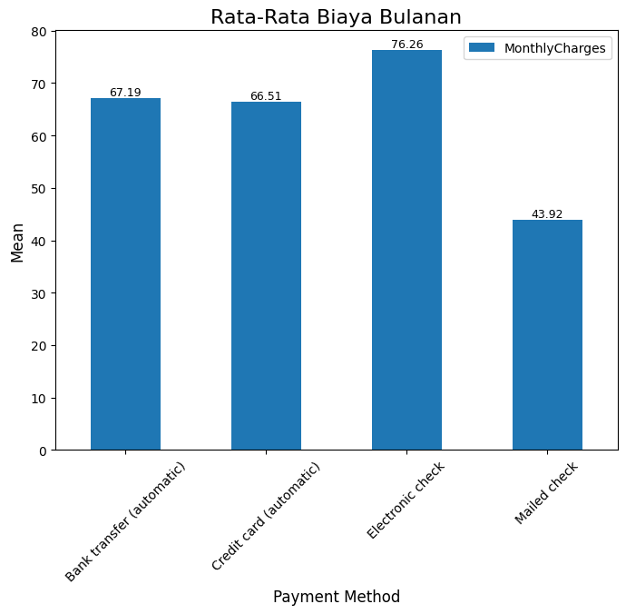

```python
fig, ax = plt.subplots(figsize=(8, 6))
df_monthly.plot(kind='bar', ax=ax)

# Set title and labels
plt.title('Rata-Rata Biaya Bulanan', fontsize=16)
ax.set_xlabel('Payment Method', fontsize=12)
ax.set_ylabel('Mean', fontsize=12)

# Annotate the bar with the value
for index, value in enumerate(df_monthly['MonthlyCharges']):
    ax.text(index, value, str(round(value, 2)), ha='center', va='bottom', fontsize=9)

# Optionally, rotate the x-axis labels for better readability
ax.tick_params(axis='x', rotation=45)

plt.legend()
plt.show()
```

Berdasarkan hasil plot di atas, diketahui bahwa **electronic check** merupakan metode pembayaran dengan rata-rata tertinggi tiap bulannya, yakni sebesar 76.255814

## Nomor 2

Jika masa berlangganan (tenure) dikelompokkan menjadi sebagai berikut:  
● low: User dengan tenure < 21 bulan  
● medium: User dengan tenure 21 - 40 bulan  
● high: User dengan tenure > 40 bulan  
Buatlah grafik yang menunjukkan jumlah pelanggan berdasarkan pengelompokkan tersebut!

```python
df['TenureGroup'] = np.where(df['tenure'] < 21, 'Low',
                    np.where(df['tenure'] < 40, 'Medium', 'High'))
df.head()
```

|  | customerID | gender | SeniorCitizen | Partner | Dependents | tenure | PhoneService | MultipleLines | InternetService | OnlineSecurity | ... | TechSupport | StreamingTV | StreamingMovies | Contract | PaperlessBilling | PaymentMethod | MonthlyCharges | TotalCharges | Churn | TenureGroup |
| --- | --- | --- | --- | --- | --- | --- | --- | --- | --- | --- | --- | --- | --- | --- | --- | --- | --- | --- | --- | --- | --- |
| 0 | 7590-VHVEG | Female | 0 | Yes | No | 1 | No | No phone service | DSL | No | ... | No | No | No | Month-to-month | Yes | Electronic check | 29.85 | 29.85 | No | Low |
| 1 | 5575-GNVDE | Male | 0 | No | No | 34 | Yes | No | DSL | Yes | ... | No | No | No | One year | No | Mailed check | 56.95 | 1889.5 | No | Medium |
| 2 | 3668-QPYBK | Male | 0 | No | No | 2 | Yes | No | DSL | Yes | ... | No | No | No | Month-to-month | Yes | Mailed check | 53.85 | 108.15 | Yes | Low |
| 3 | 7795-CFOCW | Male | 0 | No | No | 45 | No | No phone service | DSL | Yes | ... | Yes | No | No | One year | No | Bank transfer (automatic) | 42.30 | 1840.75 | No | High |
| 4 | 9237-HQITU | Female | 0 | No | No | 2 | Yes | No | Fiber optic | No | ... | No | No | No | Month-to-month | Yes | Electronic check | 70.70 | 151.65 | Yes | Low |

5 rows × 22 columns

```python
df_tenure = df.groupby('TenureGroup').agg({'customerID': 'count'})
df_tenure
```

| TenureGroup | customerID |
| --- | --- |
| High | 2821 |
| Low | 2878 |
| Medium | 1344 |

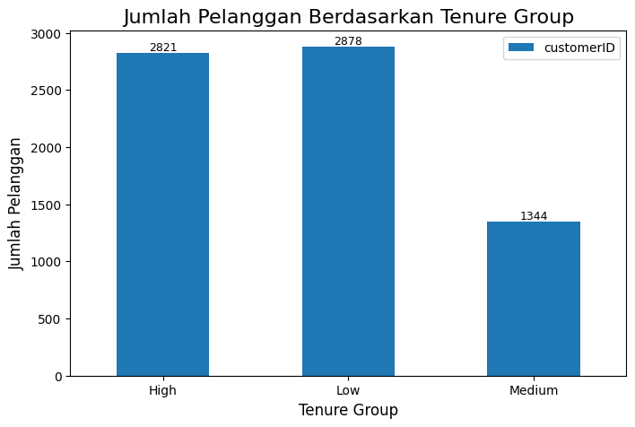

```python
fig, ax = plt.subplots(figsize=(8, 5))
df_tenure.plot(kind='bar', ax=ax)


# Set title and labels
plt.title('Jumlah Pelanggan Berdasarkan Tenure Group', fontsize=16)
ax.set_xlabel('Tenure Group', fontsize=12)
ax.set_ylabel('Jumlah Pelanggan', fontsize=12)

# Annotate the bar with the value
for index, value in enumerate(df_tenure['customerID']):
    ax.text(index, value, str(round(value, 2)), ha='center', va='bottom', fontsize=9)

# Optionally, rotate the x-axis labels for better readability
ax.tick_params(axis='x', rotation=0)

plt.legend()
plt.show()
```

Berdasarkan hasil plot di atas, jika masa berlangganan (tenure) dikelompokkan menjadi tiga kategori, yakni high, low, dan medium, maka diketahui bahwa jumlah pelanggan tertinggi berada pada kategori low sebanyak 2878 pelanggan.  
Namun demikian, jumlah pelanggan berdasarkan kategori tenure **low** dan **high** hanya memiliki selisih 57 pelanggan.  
Sementara itu, kategori **medium** jauh di bawah **low** dan **high** yakni hanya sebanyak 1344 pelanggan.

# Nomor 3

Apakah warga senior banyak yang menggunakan layanan telepon?

```python
df.head()
```

|  | customerID | gender | SeniorCitizen | Partner | Dependents | tenure | PhoneService | MultipleLines | InternetService | OnlineSecurity | ... | TechSupport | StreamingTV | StreamingMovies | Contract | PaperlessBilling | PaymentMethod | MonthlyCharges | TotalCharges | Churn | TenureGroup |
| --- | --- | --- | --- | --- | --- | --- | --- | --- | --- | --- | --- | --- | --- | --- | --- | --- | --- | --- | --- | --- | --- |
| 0 | 7590-VHVEG | Female | 0 | Yes | No | 1 | No | No phone service | DSL | No | ... | No | No | No | Month-to-month | Yes | Electronic check | 29.85 | 29.85 | No | Low |
| 1 | 5575-GNVDE | Male | 0 | No | No | 34 | Yes | No | DSL | Yes | ... | No | No | No | One year | No | Mailed check | 56.95 | 1889.5 | No | Medium |
| 2 | 3668-QPYBK | Male | 0 | No | No | 2 | Yes | No | DSL | Yes | ... | No | No | No | Month-to-month | Yes | Mailed check | 53.85 | 108.15 | Yes | Low |
| 3 | 7795-CFOCW | Male | 0 | No | No | 45 | No | No phone service | DSL | Yes | ... | Yes | No | No | One year | No | Bank transfer (automatic) | 42.30 | 1840.75 | No | High |
| 4 | 9237-HQITU | Female | 0 | No | No | 2 | Yes | No | Fiber optic | No | ... | No | No | No | Month-to-month | Yes | Electronic check | 70.70 | 151.65 | Yes | Low |

5 rows × 22 columns

```python
df3 = df.groupby(['SeniorCitizen','PhoneService'])['customerID'].nunique().reset_index(name='unique_value')
df3
```

|  | SeniorCitizen | PhoneService | unique_value |
| --- | --- | --- | --- |
| 0 | 0 | No | 578 |
| 1 | 0 | Yes | 5323 |
| 2 | 1 | No | 104 |
| 3 | 1 | Yes | 1038 |

```python
df4 = df.groupby(['SeniorCitizen'])['customerID'].nunique().reset_index(name='all')
df4
```

|  | SeniorCitizen | all |
| --- | --- | --- |
| 0 | 0 | 5901 |
| 1 | 1 | 1142 |

```python
df_merge =  df3.merge(df4,
      left_on = 'SeniorCitizen',
      right_on = 'SeniorCitizen',
      how = 'left'
      )
df_merge
```

|  | SeniorCitizen | PhoneService | unique_value | all |
| --- | --- | --- | --- | --- |
| 0 | 0 | No | 578 | 5901 |
| 1 | 0 | Yes | 5323 | 5901 |
| 2 | 1 | No | 104 | 1142 |
| 3 | 1 | Yes | 1038 | 1142 |

```python
df_merge['persentase']= (df_merge['unique_value'] / df_merge['all']) * 100
df_merge
```

|  | SeniorCitizen | PhoneService | unique_value | all | persentase |
| --- | --- | --- | --- | --- | --- |
| 0 | 0 | No | 578 | 5901 | 9.79495 |
| 1 | 0 | Yes | 5323 | 5901 | 90.20505 |
| 2 | 1 | No | 104 | 1142 | 9.10683 |
| 3 | 1 | Yes | 1038 | 1142 | 90.89317 |

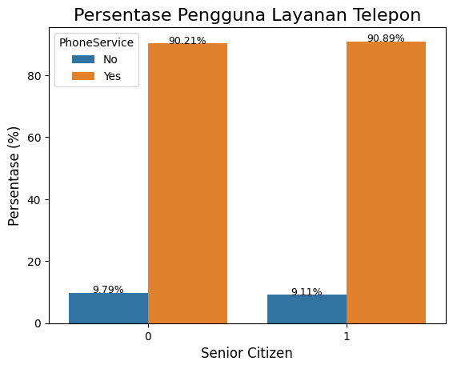

```python
# Create the bar plot
ax = sns.barplot(x=df_merge['SeniorCitizen'], y=df_merge['persentase'], hue=df_merge['PhoneService'])

# Annotate the bar with the value
for p in ax.patches:
    height = p.get_height()
    ax.annotate(f'{height:.2f}%', (p.get_x() + p.get_width() / 2, height), ha='center', fontsize=9)

#Add label and title
plt.xlabel('Senior Citizen', fontsize=12)
plt.ylabel('Persentase (%)', fontsize=12)
plt.title('Persentase Pengguna Layanan Telepon', fontsize=16)

# Show the plot
plt.show()
```

# Nomor 4

Bagaimana distribusi dari total biaya?

```python
df_cust = pd.read_csv(r'F:\COURSE\RAKAMIN\WEEK 8 - Data Visualization\WA_Fn-UseC_-Telco-Customer-Churn.csv')
df_cust.head()
```

|  | customerID | gender | SeniorCitizen | Partner | Dependents | tenure | PhoneService | MultipleLines | InternetService | OnlineSecurity | ... | DeviceProtection | TechSupport | StreamingTV | StreamingMovies | Contract | PaperlessBilling | PaymentMethod | MonthlyCharges | TotalCharges | Churn |
| --- | --- | --- | --- | --- | --- | --- | --- | --- | --- | --- | --- | --- | --- | --- | --- | --- | --- | --- | --- | --- | --- |
| 0 | 7590-VHVEG | Female | 0 | Yes | No | 1 | No | No phone service | DSL | No | ... | No | No | No | No | Month-to-month | Yes | Electronic check | 29.85 | 29.85 | No |
| 1 | 5575-GNVDE | Male | 0 | No | No | 34 | Yes | No | DSL | Yes | ... | Yes | No | No | No | One year | No | Mailed check | 56.95 | 1889.5 | No |
| 2 | 3668-QPYBK | Male | 0 | No | No | 2 | Yes | No | DSL | Yes | ... | No | No | No | No | Month-to-month | Yes | Mailed check | 53.85 | 108.15 | Yes |
| 3 | 7795-CFOCW | Male | 0 | No | No | 45 | No | No phone service | DSL | Yes | ... | Yes | Yes | No | No | One year | No | Bank transfer (automatic) | 42.30 | 1840.75 | No |
| 4 | 9237-HQITU | Female | 0 | No | No | 2 | Yes | No | Fiber optic | No | ... | No | No | No | No | Month-to-month | Yes | Electronic check | 70.70 | 151.65 | Yes |

5 rows × 21 columns

```python
df_cust['TotalCharges']=df_cust['TotalCharges'].replace(' ','0.0').astype(float)
df_cust['TotalCharges'].describe()
```

```
count    7043.000000
mean     2279.734304
std      2266.794470
min         0.000000
25%       398.550000
50%      1394.550000
75%      3786.600000
max      8684.800000
Name: TotalCharges, dtype: float64
```

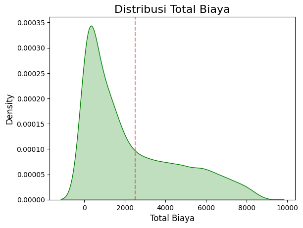

```python
sns.kdeplot(data=df_cust['TotalCharges'], shade=True, color='green')

plt.axvline(x=2500, color='red', alpha= 0.5, linestyle='dashed', linewidth=1.5)

# Add labels and title
plt.xlabel('Total Biaya', fontsize=12)
plt.ylabel('Density', fontsize=12)
plt.title('Distribusi Total Biaya', fontsize=16)

# Display the plot
plt.show()
```

Proses analisa data pada poin ini mengunakan KDE plot untuk menampilkan visualisasi.  
Adapun vertical line pada plot ini digunakan untuk membantu memahami distribusi data sehingga diketahui bahwa distribusi data terjadi secara positif skew.  
Skewness yang bernilai positif terlihat pada ekor distribusi yang berada di sebelah kanan nilai terbanyak,  
distribusi total biaya customer dalam kasus ini dominan berada di nilai rendah.

# Nomor 5

Apakah pelanggan yang memiliki biaya bulanan lebih tinggi akan cenderung untuk berhenti berlangganan (churn)?

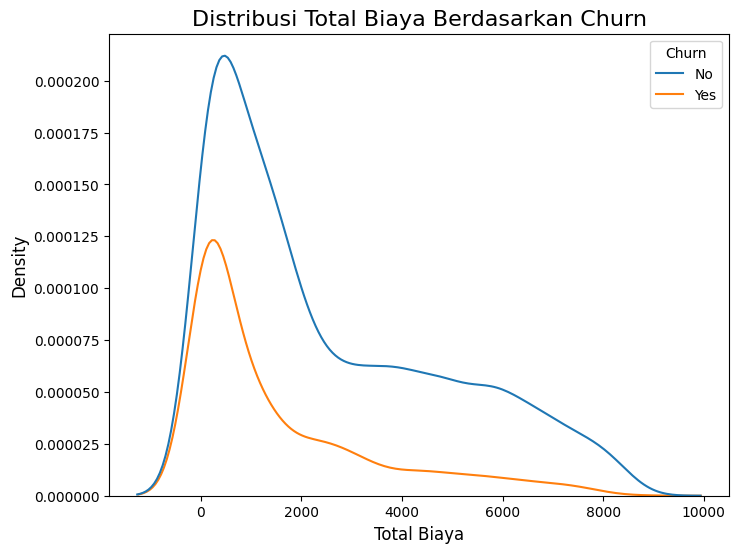

```python
plt.figure(figsize=(8,6))
sns.kdeplot(x='TotalCharges', data=df_cust, hue='Churn')

# Add labels and title
plt.xlabel('Total Biaya', fontsize=12)
plt.ylabel('Density', fontsize=12)
plt.title('Distribusi Total Biaya Berdasarkan Churn', fontsize=16)
# Display the plot plt.show()
```

# Nomor 6

Bagaimana pengaruh memiliki pasangan & tanggungan terhadap tingkat churn pelanggan?

```python
df_cust.head()
```

|  | customerID | gender | SeniorCitizen | Partner | Dependents | tenure | PhoneService | MultipleLines | InternetService | OnlineSecurity | ... | DeviceProtection | TechSupport | StreamingTV | StreamingMovies | Contract | PaperlessBilling | PaymentMethod | MonthlyCharges | TotalCharges | Churn |
| --- | --- | --- | --- | --- | --- | --- | --- | --- | --- | --- | --- | --- | --- | --- | --- | --- | --- | --- | --- | --- | --- |
| 0 | 7590-VHVEG | Female | 0 | Yes | No | 1 | No | No phone service | DSL | No | ... | No | No | No | No | Month-to-month | Yes | Electronic check | 29.85 | 29.85 | No |
| 1 | 5575-GNVDE | Male | 0 | No | No | 34 | Yes | No | DSL | Yes | ... | Yes | No | No | No | One year | No | Mailed check | 56.95 | 1889.50 | No |
| 2 | 3668-QPYBK | Male | 0 | No | No | 2 | Yes | No | DSL | Yes | ... | No | No | No | No | Month-to-month | Yes | Mailed check | 53.85 | 108.15 | Yes |
| 3 | 7795-CFOCW | Male | 0 | No | No | 45 | No | No phone service | DSL | Yes | ... | Yes | Yes | No | No | One year | No | Bank transfer (automatic) | 42.30 | 1840.75 | No |
| 4 | 9237-HQITU | Female | 0 | No | No | 2 | Yes | No | Fiber optic | No | ... | No | No | No | No | Month-to-month | Yes | Electronic check | 70.70 | 151.65 | Yes |

5 rows × 21 columns

```python
df_cust['PartnerDependents'] = df_cust['Partner'] + ' ' + df_cust['Dependents']
df_cust1 = df_cust.groupby(['PartnerDependents','Churn']).agg({'customerID':'nunique'}).reset_index()
df_cust1
```

|  | PartnerDependents | Churn | customerID |
| --- | --- | --- | --- |
| 0 | No No | No | 2157 |
| 1 | No No | Yes | 1123 |
| 2 | No Yes | No | 284 |
| 3 | No Yes | Yes | 77 |
| 4 | Yes No | No | 1233 |
| 5 | Yes No | Yes | 420 |
| 6 | Yes Yes | No | 1500 |
| 7 | Yes Yes | Yes | 249 |

```python
df_cust2 = df_cust.groupby(['PartnerDependents']).agg({'customerID':'nunique'}).rename(columns={'customerID':'TotalCustomers'}).reset_index()
df_cust2
```

|  | PartnerDependents | TotalCustomers |
| --- | --- | --- |
| 0 | No No | 3280 |
| 1 | No Yes | 361 |
| 2 | Yes No | 1653 |
| 3 | Yes Yes | 1749 |

```python
df_cust3 = df_cust1.merge(df_cust2,
                          on = 'PartnerDependents')
df_cust3
```

|  | PartnerDependents | Churn | customerID | TotalCustomers |
| --- | --- | --- | --- | --- |
| 0 | No No | No | 2157 | 3280 |
| 1 | No No | Yes | 1123 | 3280 |
| 2 | No Yes | No | 284 | 361 |
| 3 | No Yes | Yes | 77 | 361 |
| 4 | Yes No | No | 1233 | 1653 |
| 5 | Yes No | Yes | 420 | 1653 |
| 6 | Yes Yes | No | 1500 | 1749 |
| 7 | Yes Yes | Yes | 249 | 1749 |

```python
df_cust3['Persentase']= round((df_cust3['customerID']/df_cust3['TotalCustomers'])*100,2)
df_cust3
```

|  | PartnerDependents | Churn | customerID | TotalCustomers | Persentase |
| --- | --- | --- | --- | --- | --- |
| 0 | No No | No | 2157 | 3280 | 65.76 |
| 1 | No No | Yes | 1123 | 3280 | 34.24 |
| 2 | No Yes | No | 284 | 361 | 78.67 |
| 3 | No Yes | Yes | 77 | 361 | 21.33 |
| 4 | Yes No | No | 1233 | 1653 | 74.59 |
| 5 | Yes No | Yes | 420 | 1653 | 25.41 |
| 6 | Yes Yes | No | 1500 | 1749 | 85.76 |
| 7 | Yes Yes | Yes | 249 | 1749 | 14.24 |

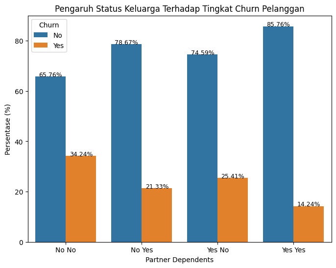

```python
plt.figure(figsize=(8, 6))

# Create a bar plot
ax = sns.barplot(data=df_cust3, x='PartnerDependents', y='Persentase', hue='Churn')

# Annotate the bar with the value
for p in ax.patches:
    height = p.get_height()
    ax.annotate(f'{height:.2f}%', (p.get_x() + p.get_width() / 2, height), ha='center', fontsize=9)

# Add labels and title
plt.xlabel('Partner Dependents')
plt.ylabel('Persentase (%)')
plt.title('Pengaruh Status Keluarga Terhadap Tingkat Churn Pelanggan')

#Show the plot
plt.show()
```

Sehingga berdasarkan proses analisa, dapat disimpulkan bahwa status keluarga dalam aspek pasangan dan tanggungan memiliki pengaruh terhadap tingkat churn pelanggan.

# Nomor 7

Buatlah insight dari data telco customer, dan sertakan storyline pada visualisasi tersebut dengan memanfaatkan atribut tenure, contract, monthly charges, status*, jumlah pelanggan, dan churn!

```python
df_cust.head()
```

|  | customerID | gender | SeniorCitizen | Partner | Dependents | tenure | PhoneService | MultipleLines | InternetService | OnlineSecurity | ... | TechSupport | StreamingTV | StreamingMovies | Contract | PaperlessBilling | PaymentMethod | MonthlyCharges | TotalCharges | Churn | PartnerDependents |
| --- | --- | --- | --- | --- | --- | --- | --- | --- | --- | --- | --- | --- | --- | --- | --- | --- | --- | --- | --- | --- | --- |
| 0 | 7590-VHVEG | Female | 0 | Yes | No | 1 | No | No phone service | DSL | No | ... | No | No | No | Month-to-month | Yes | Electronic check | 29.85 | 29.85 | No | Yes No |
| 1 | 5575-GNVDE | Male | 0 | No | No | 34 | Yes | No | DSL | Yes | ... | No | No | No | One year | No | Mailed check | 56.95 | 1889.50 | No | No No |
| 2 | 3668-QPYBK | Male | 0 | No | No | 2 | Yes | No | DSL | Yes | ... | No | No | No | Month-to-month | Yes | Mailed check | 53.85 | 108.15 | Yes | No No |
| 3 | 7795-CFOCW | Male | 0 | No | No | 45 | No | No phone service | DSL | Yes | ... | Yes | No | No | One year | No | Bank transfer (automatic) | 42.30 | 1840.75 | No | No No |
| 4 | 9237-HQITU | Female | 0 | No | No | 2 | Yes | No | Fiber optic | No | ... | No | No | No | Month-to-month | Yes | Electronic check | 70.70 | 151.65 | Yes | No No |

5 rows × 22 columns

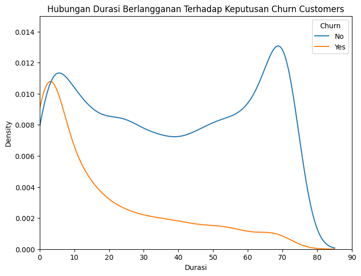

```python
plt.figure(figsize=(8,6))
sns.kdeplot(x='tenure', data=df_cust, hue='Churn')

# Add labels and title
plt.xlabel('Durasi')
plt.ylabel('Density')
plt.title('Hubungan Durasi Berlangganan Terhadap Keputusan Churn Customers')

plt.xlim(0,90)
plt.ylim(0,0.015)

# Display the plot
plt.show()
```

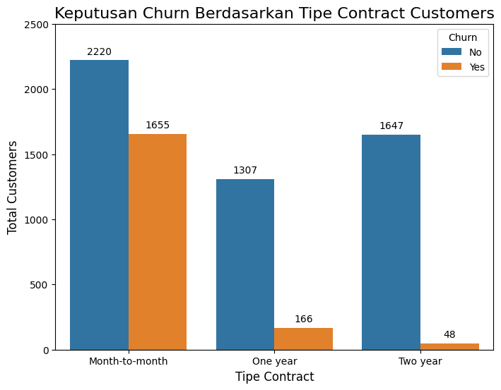

```python
contract_churn = df_cust.groupby(['Contract', 'Churn']).size().reset_index(name='Count')

plt.figure(figsize=(8,6))
ax=sns.barplot(x='Contract', y='Count', hue='Churn',data=contract_churn)

#Annotation
for p in ax.patches:
    ax.annotate(format(p.get_height(), '.0f'),
                (p.get_x() + p.get_width() / 2., p.get_height()),
                ha = 'center', va = 'center',
                xytext = (0, 9),
                textcoords = 'offset points')

# Add labels and title
plt.xlabel('Tipe Contract', fontsize=12)
plt.ylabel('Total Customers',fontsize=12)
plt.title('Keputusan Churn Berdasarkan Tipe Contract Customers', fontsize=16)

plt.ylim(0,2500)

# Display the plot
plt.show()
```

Dalam plot ini, kita menyelidiki bagaimana keputusan Churn (berhenti berlangganan) dipengaruhi oleh tipe kontrak (Contract) pelanggan.  
Dengan menggunakan tiga tipe kontrak yang berbeda, yaitu **Month-to-month,** **One year**, dan **Two year**  
kita dapat memahami bagaimana keputusan Churn dipengaruhi oleh tipe kontrak ini.  
Dari plot ini, kita dapat melihat perbandingan jumlah pelanggan yang Churn dan yang tidak Churn untuk setiap tipe kontrak  
Penggunaan anotasi pada setiap batang bar memungkinkan kita melihat angka yang lebih spesifik dalam plot, sehingga kita dapat dengan cepat membandingkan jumlah pelanggan dalam setiap kategori.

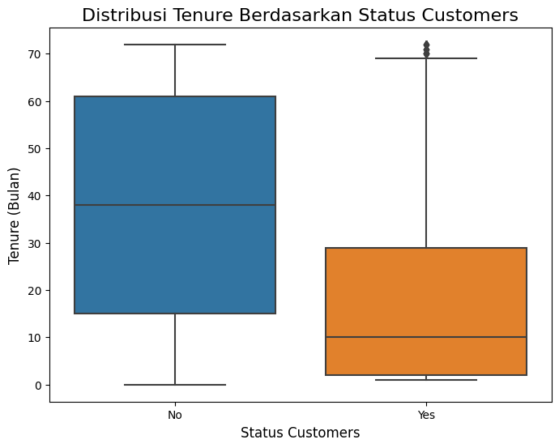

```python
plt.figure(figsize=(8,6))
ax=sns.boxplot(x=df_cust['Churn'],y=df_cust['tenure'],data=df_cust)

# Add labels and title
plt.xlabel('Status Customers', fontsize=12)
plt.ylabel('Tenure (Bulan)',fontsize=12)
plt.title('Distribusi Tenure Berdasarkan Status Customers', fontsize= 16)
# Display the plot
plt.show()
```

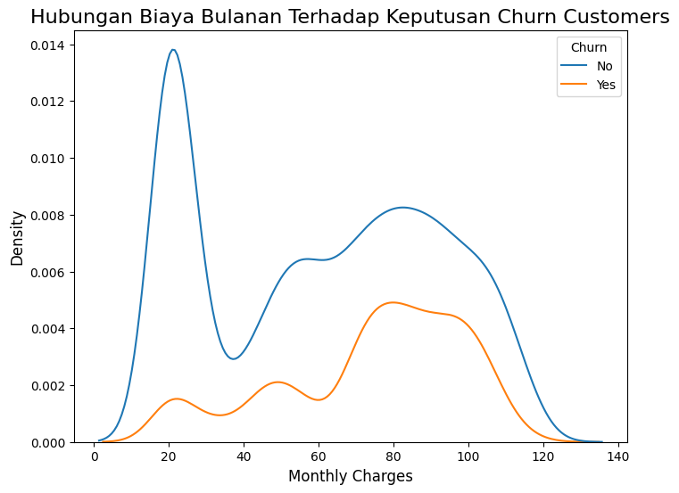

```python
plt.figure(figsize=(8,6))
sns.kdeplot(x='MonthlyCharges', data=df_cust, hue='Churn')

plt.xlabel('Monthly Charges', fontsize=12)
plt.ylabel('Density',fontsize=12)
plt.title('Hubungan Biaya Bulanan Terhadap Keputusan Churn Customers', fontsize= 16)

# Display the plot
plt.show()
```

Status pelanggan (Churn atau tidak Churn) digunakan untuk membedakan sebaran lama berlangganan (Tenure) antara pelanggan yang Churn dan pelanggan yang tidak Churn sehingga diketahui perbedaan masa berlangganan antara pelanggan yang berbeda berdasarkan statusnya.